# Study 1: CCL Members

# Descriptives

### Race / Ethnicity

```r
ccl %>%
  group_by(race) %>%
  summarize(count = n(),
            percent = n()/162*100) %>%
  kable(col.names = c("Race/Ethnicity",
                      "Counts",
                      "Percent")) %>%
  kable_styling(bootstrap_options = "striped", full_width = FALSE, position = "left") # How do I get percent to stop at 2 decimal places?
```

| Race/Ethnicity | Counts | Percent |
| --- | --- | --- |
| Asian | 2 | 1.234568 |
| Multi-racial (please specify) | 1 | 0.617284 |
| Other (please specify) | 1 | 0.617284 |
| White / Caucasian | 157 | 96.913580 |
| NA | 1 | 0.617284 |

```r
# Multi-racial (open-ended)
ccl %>%
  group_by(race_6_text) %>%
  summarise(count = n()) %>%
  kable(col.names = c("Race/Ethnicity: Multi-racial - Text",
                      "Counts")) %>%
  kable_styling(bootstrap_options = "striped", full_width = FALSE, position = "left")
```

| Race/Ethnicity: Multi-racial - Text | Counts |
| --- | --- |
| White, Hispanic | 1 |
| NA | 161 |

```r
# Other (open-ended)
ccl %>%
  group_by(race_7_text) %>%
  summarise(count = n()) %>%
  kable(col.names = c("Race/Ethnicity: Other - Text",
                      "Counts")) %>%
  kable_styling(bootstrap_options = "striped", full_width = FALSE, position = "left")
```

| Race/Ethnicity: Other - Text | Counts |
| --- | --- |
| European | 1 |
| NA | 161 |

1 ‘multi-racial’ person identified as “white and hispanic”; 1 ‘other’ identified as “European.”

### Age, household income, gender

### Age

Participants ranged from 18 to 84 years old (median age = 66, sd = 16.81 years). Three participants wrote in their own responses: “Older than you,” “70 (Retired),” “over 60.”

```r
## AGE

# First I created a subset of just the age variable so I could filter out the text responses and convert this variable to numeric. After examining the variable, I saw the 3 text responses so I'm going to filter those out here:

age_subset <- ccl %>%
  select(age) %>%
  filter(age != "70 (Retired)") %>%
  filter(age != "Older than you") %>%
  filter(age != "over 60")

#Convert the age variable to numeric
age_subset <- age_subset %>%
  mutate(age = as.numeric(age)) %>%
  drop_na()

# Find descriptives
#mean(age_subset$age) # 60.37
#sd(age_subset$age) # 16.81
#min(age_subset$age) # 18
#max(age_subset$age) # 84
#median(age_subset$age) # 66
```

### Household income

Median household income category was 5: $50,001 to $75,000. *Still need to figure out how to label tick marks on x-axis.

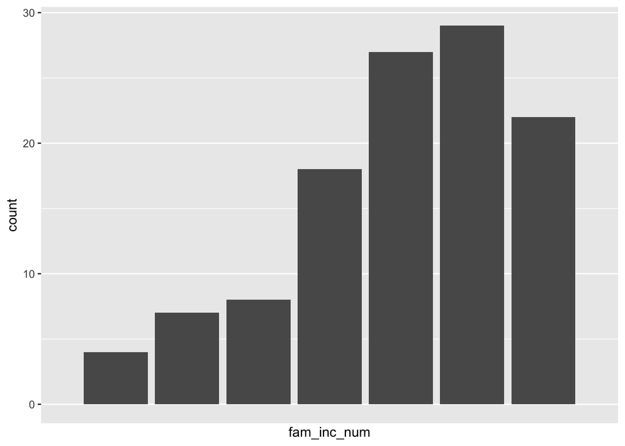

```r
## HOUSEHOLD INCOME

#First, change family income into a factor variable

ccl <- ccl %>%
  mutate(fam_inc_num = case_when(
    fam_inc == "Under $15,000" ~ 1,
    fam_inc == "$15,001 - $25,000" ~ 2,
    fam_inc == "$25,001 - $35,000" ~ 3,
    fam_inc == "$35,001 - $50,000" ~ 4,
    fam_inc == "$50,001 - $75,000" ~ 5,
    fam_inc == "$75,001 - $100,000" ~ 6,
    fam_inc == "$100,001 - $150,000" ~ 7,
    fam_inc == "$Over 150,000" ~ 8))

#IDK why the labeling doesn't work

ggplot(data = ccl, aes(x = fam_inc_num)) +
  geom_histogram(stat = "count") +
  theme(axis.text.x = element_text(angle = 90)) +
  scale_x_discrete(breaks=c("1","2","3","4","5","6","7"),
                      labels=c("Under $15,000", "$15,001 - $25,000", "$25,001 - $35,000",
                  "$35,001 - $50,000","$50,001 - $75,000","$75,001 - $100,000",
                  "$100,001 - $150,000"))
```

```r
#median(ccl$fam_inc_num, na.rm = TRUE) # 5
#min(ccl$fam_inc_num, na.rm = TRUE) # 1
#max(ccl$fam_inc_num, na.rm = TRUE) # 7
```

### Gender

```r
## GENDER

ccl %>%
  group_by(gender) %>%
  summarise(count = n(),
            percent = n()/(64+97+1)*100) %>%
  kable(col.names = c("Gender",
                      "Counts",
                      "Percent")) %>%
  kable_styling(bootstrap_options = "striped", full_width = FALSE, position = "left")
```

| Gender | Counts | Percent |
| --- | --- | --- |
| Female | 64 | 39.506173 |
| Male | 97 | 59.876543 |
| Prefer not to answer | 1 | 0.617284 |

### Political orientation

```r
ccl %>%
  group_by(ideology) %>%
  summarise(count = n()) %>%
  kable(col.names = c("Political Ideology",
                      "Counts")) %>%
  kable_styling(bootstrap_options = "striped", full_width = FALSE, position = "left")
```

| Political Ideology | Counts |
| --- | --- |
| Conservative | 7 |
| Liberal | 73 |
| Moderate | 44 |
| Not sure | 1 |
| Prefer not to answer | 4 |
| Very conservative | 1 |
| Very liberal | 32 |

```r
ccl <- ccl %>%
  mutate(pol_7_pt = case_when(
    dem_strong_weak == "Strong Democrat" ~ 1,
    dem_strong_weak == "Not Very Strong Democrat" ~ 2,
    closer_dem_rep == "Closer to Democratic Party" ~ 3,
    closer_dem_rep == "Neither" ~ 4,
    closer_dem_rep == "Closer to Republican Party" ~ 5,
    rep_strong_weak == "Not Very Strong Republican" ~ 6,
    rep_strong_weak == "Strong Republican" ~ 7
  ))

#mean(ccl$pol_7_pt) #2.16

ccl <- ccl %>%
  mutate(pol_7_pt_char = case_when(
    dem_strong_weak == "Strong Democrat" ~ "Strong Democrat",
    dem_strong_weak == "Not Very Strong Democrat" ~ "Not Very Strong Democrat",
    closer_dem_rep == "Closer to Democratic Party" ~ "Closer to Democratic Party",
    closer_dem_rep == "Neither" ~ "Neither",
    closer_dem_rep == "Closer to Republican Party" ~ "Closer to Republican Party",
    rep_strong_weak == "Not Very Strong Republican" ~ "Not Very Strong Republican",
    rep_strong_weak == "Strong Republican" ~ "Strong Republican"
  ))

ccl %>%
  group_by(pol_7_pt) %>%
  summarise(count = n()) %>%
  kable(col.names = c("Political Party Identification",
                      "Counts")) %>%
  kable_styling(bootstrap_options = "striped", full_width = FALSE, position = "left")
```

| Political Party Identification | Counts |
| --- | --- |
| 1 | 72 |
| 2 | 26 |
| 3 | 41 |
| 4 | 17 |
| 5 | 2 |
| 6 | 3 |
| 7 | 1 |

# Participants’ answers on the similarity questions

Check that they reveal expected levels of variance in the expected population: 27.78% enjoy relaxing vacations (vs. 72.22% adventurous), 17.90% enjoy scary movies, and 71.6% enjoy camping (vs. 27.16% staying in and watching TV shows).

```r
ccl %>%
  group_by(vacation) %>%
  summarize(count = n(),
            percent = n()/162*100) %>%
   kable(col.names = c("Vacation Preference",
                      "Counts",
                      "Percent")) %>%
  kable_styling(bootstrap_options = "striped", full_width = FALSE, position = "left")
```

| Vacation Preference | Counts | Percent |
| --- | --- | --- |
| Adventurous | 117 | 72.22222 |
| Relaxing | 45 | 27.77778 |

```r
ccl %>%
  group_by(scary_movie) %>%
  summarize(count = n(),
            percent = n()/162*100) %>%
   kable(col.names = c("Enjoy Scary Movies?",
                      "Counts",
                      "Percent")) %>%
  kable_styling(bootstrap_options = "striped", full_width = FALSE, position = "left")
```

| Enjoy Scary Movies? | Counts | Percent |
| --- | --- | --- |
| No | 133 | 82.09877 |
| Yes | 29 | 17.90123 |

```r
ccl %>%
  group_by(outdoor_art) %>%
  summarize(count = n(),
            percent = n()/162*100) %>%
   kable(col.names = c("Prefer Camping or Staying In and Watching TV Shows?",
                      "Counts",
                      "Percent")) %>%
  kable_styling(bootstrap_options = "striped", full_width = FALSE, position = "left")
```

| Prefer Camping or Staying In and Watching TV Shows? | Counts | Percent |
| --- | --- | --- |
| Camping | 116 | 71.604938 |
| Staying in and watching TV shows | 44 | 27.160494 |
| NA | 2 | 1.234568 |

# How many people in each condition?

80 in the dissimilarity condition, 82 in the similarity condition.

```r
ccl %>%
  group_by(group) %>%
  summarize(count = n()) %>%
  kable(col.names = c("Experimental Condition",
                      "Counts")) %>%
  kable_styling(bootstrap_options = "striped", full_width = FALSE, position = "left")
```

| Experimental Condition | Counts |
| --- | --- |
| Different | 80 |
| Similar | 82 |

# Calculate stereotyping and projection constructs

For each reason to support the Energy Innovation & Carbon Dividend Act for each participant, a multiple regression predicting target responses with self-responses and typical business owner responses was computed. The mean standardized beta weights were then used as measures of projection (the self-response beta) and stereotyping (the typical businessman response beta)

```r
# Create a new row called `id` which assigns each Ss an ID number based on the row they are in
ccl <- ccl %>%
  mutate(id = row_number())

# Filter for each participant one by one and calculate the regressions. Note what standardized beta is for each participant

# Create vectors (length of 200 ) of a) the projection standardized betas and b) the stereotyping standardized betas

# Merge the vectors of the standardized betas for each participant into the original dataset


# Projection: regressions between self-ratings and Robert ratings for each of the 8 reasons


# Mean standardized beta for projection:


# Stereotyping: regressions between typical businessman-ratings and Robert ratings for each of the 8 reasons


# Mean standardized beta for stereotyping:
```

# Effects of similarity on projection and stereotyping

Conduct repeated-measures ANOVA to examine the effect of the similarity manipulation and (time - is that the second factor because participants completed 2 measures to get their S and P scores?) on the projection and stereotyping measures. (from manuscript “the two-level factor of projection and stereotyping”)

Use [this resource](https://www.datanovia.com/en/lessons/repeated-measures-anova-in-r/#data-preparation-1)

See example on two-way repeated measures ANOVA.

First, verify that the data meets the required assumptions for two-way repeated measures ANOVA:

```r
# Self-ratings, robert ratings, and businessman ratings are analogous to t1, t2, t3 in the example
```

# Visualize the data

```r
#Calculate stereotyping and projection means by similarity condition
#Use group_by, summarize


#Look at Montecito analysis code to make ggplot bar charts of means by similarity condition
```

# Create subset of data of interest to CCL

Select the following two variables of interest to the CCL team, write and save as Excel.

`why_advocacy`: “Why did you get involved with climate advocacy? What were the factors that led you to get involved with CCL?” `feedback_ccl`: “What feedback do you have about your experience volunteering with CCL? Is it a welcoming space for you as a volunteer?”

```r
# Select columns of interest to Brett: `why_advocacy` and `feedback_ccl`

why_advocacy <- ccl %>%
  select(response_id, why_advocacy) %>%
  drop_na()

feedback_ccl <- ccl %>%
  select(response_id, feedback_ccl) %>%
  drop_na()

# Save subsets as new dataframes in the `data` subfolder

write_xlsx(why_advocacy, here("data","why_advocacy.xlsx"))
write_xlsx(feedback_ccl, here("data","feedback_ccl.xlsx"))
```